# Project 2B: Streaming Data

Preet Piyush Patel, Ali Lmalki, Jocelyn Pelcastre-Gonzalez

Thursday, April 14, 2022 @ 03:22 PM

## Setup

### Packages Used

```r
library(tidyverse)
library(skimr)
library(waffle)
```

### Background of the Data

The datasets were downloaded from [Disney+ Movies and TV Shows | Kaggle](https://www.kaggle.com/datasets/shivamb/disney-movies-and-tv-shows) and [TV shows on Netflix, Prime Video, Hulu and Disney+ | Kaggle](https://www.kaggle.com/datasets/ruchi798/tv-shows-on-netflix-prime-video-hulu-and-disney). You can read about them there, including variable definitions, sources, when they were created, and other information. Load the two datasets and use `glimpse()` to explore their structures.

#### Disney+ Dataset

```r
disneypluscontent <- read_csv("~/git_repositories/STT2860S22project2/data/disneypluscontent.csv")
glimpse(disneypluscontent)
```

```
Rows: 1,368
Columns: 12
$ show_id      <chr> "s1", "s2", "s3", "s4", "s5", "s6", "s7", "s8", "s9", "s1…
$ type         <chr> "Movie", "Movie", "Movie", "TV Show", "TV Show", "TV Show…
$ title        <chr> "A Spark Story", "Spooky Buddies", "The Fault in Our Star…
$ director     <chr> "Jason Sterman, Leanne Dare", "Robert Vince", "Josh Boone…
$ cast         <chr> "Apthon Corbin, Louis Gonzales", "Tucker Albrizzi, Diedri…
$ country      <chr> NA, "United States, Canada", "United States", "United Sta…
$ date_added   <date> 2021-09-24, 2021-09-24, 2021-09-24, 2021-09-22, 2021-09-…
$ release_year <dbl> 2021, 2011, 2014, 2019, 2021, 2021, 2009, 2021, 2016, 202…
$ rating       <chr> "TV-PG", "G", "PG-13", "TV-PG", "TV-Y", "TV-PG", "PG", "T…
$ duration     <chr> "88 min", "93 min", "127 min", "2 Seasons", "1 Season", "…
$ listed_in    <chr> "Documentary", "Comedy, Fantasy, Kids", "Coming of Age, D…
$ description  <chr> "Two Pixar filmmakers strive to bring their uniquely pers…
```

#### Streaming Dataset

```r
streamingcontent <-   read_csv("~/git_repositories/STT2860S22project2/data/streamingcontent.csv")
glimpse(streamingcontent)
```

```
Rows: 5,368
Columns: 10
$ ID                <dbl> 1, 2, 3, 4, 5, 6, 7, 8, 9, 10, 11, 12, 13, 14, 15, 1…
$ Title             <chr> "Breaking Bad", "Stranger Things", "Attack on Titan"…
$ Year              <dbl> 2008, 2016, 2013, 2015, 2017, 2005, 2013, 2010, 2011…
$ Age               <chr> "18+", "16+", "18+", "18+", "16+", "7+", "18+", "18+…
$ IMDb              <chr> "9.4/10", "8.7/10", "9.0/10", "8.8/10", "8.8/10", "9…
$ `Rotten Tomatoes` <chr> "100/100", "96/100", "95/100", "94/100", "93/100", "…
$ Netflix           <dbl> 1, 1, 1, 1, 1, 1, 1, 1, 1, 1, 1, 1, 1, 1, 1, 1, 1, 1…
$ Hulu              <dbl> 0, 0, 1, 0, 0, 0, 0, 0, 0, 0, 0, 1, 0, 1, 0, 0, 0, 0…
$ `Prime Video`     <dbl> 0, 0, 0, 0, 0, 1, 0, 0, 0, 0, 0, 1, 0, 1, 0, 0, 0, 0…
$ `Disney+`         <dbl> 0, 0, 0, 0, 0, 0, 0, 0, 0, 0, 0, 0, 0, 0, 0, 0, 0, 0…
```

## Analyses

### Create the Analysis Datasets

#### Dataset #1

The Disney+ dataset contains a variable that gives information about the `rating` for each program offering. Convert the variable into a factor that puts the ratings in (roughly) ascending order of age restriction/audience: `TV-Y`, `TV-Y7`, `TV-Y7-FV`, `TV-G`, `G`, `TV-PG`, `PG`, `PG-13`, `TV-14`. If the `date_added` variable is not already in date format, convert it.

```r
disneypluscontent_mutate <- disneypluscontent %>%
  group_by(rating) %>%
  mutate(rating = factor(rating, levels = c("TV-Y", "TV-Y7", "TV-Y7-FV", "TV-G", "G", "TV-PG", "PG", "PG-13", "TV-14"))) %>%
  arrange(rating) %>%
  group_by(date_added) %>%
  mutate(date_added = format(as.Date(date_added), "%m-%d-%Y"))

disneypluscontent_mutate
```

```
# A tibble: 1,368 × 12
# Groups:   date_added [151]
   show_id type    title   director cast  country date_added release_year rating
   <chr>   <chr>   <chr>   <chr>    <chr> <chr>   <chr>             <dbl> <fct>
 1 s5      TV Show Spidey… <NA>     "Ben… United… 09-22-2021         2021 TV-Y
 2 s16     TV Show Ready … <NA>      <NA> <NA>    09-15-2021         2019 TV-Y
 3 s22     TV Show Mira, … <NA>     "Lee… United… 09-08-2021         2020 TV-Y
 4 s23     TV Show Pepper… <NA>     "Kat… United… 09-08-2021         1997 TV-Y
 5 s36     TV Show Gigant… <NA>     "Dyl… France  08-25-2021         2018 TV-Y
 6 s45     TV Show Chicke… <NA>     "Ram… United… 08-11-2021         2021 TV-Y
 7 s60     TV Show Disney… <NA>     "Van… United… 07-28-2021         2018 TV-Y
 8 s61     TV Show Mickey… <NA>     "Bre… <NA>    07-28-2021         2021 TV-Y
 9 s73     TV Show Meet S… <NA>     "Ben… <NA>    07-21-2021         2021 TV-Y
10 s74     TV Show Missio… <NA>     "Jus… United… 07-21-2021         2017 TV-Y
# … with 1,358 more rows, and 3 more variables: duration <chr>,
#   listed_in <chr>, description <chr>
```

```r
disneypluscontent_mutate1 <- disneypluscontent %>%
  select(type) %>%
mutate(Movies = ifelse(type == "Movies", 1, type))
```

#### Dataset #2

From the streaming content dataset, create a new dataset by doing the following.

- Use `pivot_longer()` to gather the `Netflix`, `Hulu`, `Prime Video`, and `Disney+` variables into columns called `Service` (containing the name of the streaming service) and `YesNo` (showing the 0/1 indicator values from the original columns).
- After pivoting, filter the dataset to remove any row where `YesNo == 0` (i.e., a show is *not* on the service).
- Split the `IMDb` variable to separate the show rating from the max rating of `10`. Convert the show rating to a numerical variable.
- Split the `Rotten Tomatoes` variable to separate the show rating from the max of `100`. Convert the show rating to a numerical variable.

```r
streamingcontent_longer <- streamingcontent %>%
  pivot_longer(
    cols = `Netflix`:`Disney+`,
    names_to = "Service",
    values_to = "YesNo"
  ) %>%
  filter(YesNo == 1) %>%
  separate(
    col = IMDb,
    into = c("Show Rating", "Max Rating"),
    sep = "/",
    convert = TRUE
  ) %>%
  separate(
    col = 'Rotten Tomatoes',
    into = c("RT Show", "RT Max"),
    sep = "/",
    convert = TRUE
  )
head(streamingcontent_longer)
```

```
# A tibble: 6 × 10
     ID Title   Year Age   `Show Rating` `Max Rating` `RT Show` `RT Max` Service
  <dbl> <chr>  <dbl> <chr>         <dbl>        <int>     <int>    <int> <chr>
1     1 Break…  2008 18+             9.4           10       100      100 Netflix
2     2 Stran…  2016 16+             8.7           10        96      100 Netflix
3     3 Attac…  2013 18+             9             10        95      100 Netflix
4     3 Attac…  2013 18+             9             10        95      100 Hulu
5     4 Bette…  2015 18+             8.8           10        94      100 Netflix
6     5 Dark    2017 16+             8.8           10        93      100 Netflix
# … with 1 more variable: YesNo <dbl>
```

### Visualization 1: Violin Plot

**This plot uses Dataset #1.**

Create a violin plot of `release_year` (x-axis) grouped by `type` of program (y-axis) for programs on Disney+. Fill with a color of your choice. Add a boxplot inside the violin plot, as you did in one of the DataCamp exercises. Re-scale the x-axis so that tick marks appear at whole-decade intervals (e.g., 1980, 1990, 2000). Add an appropriate title and axis labels. Use other formatting as you choose to enhance effectiveness/appearance.

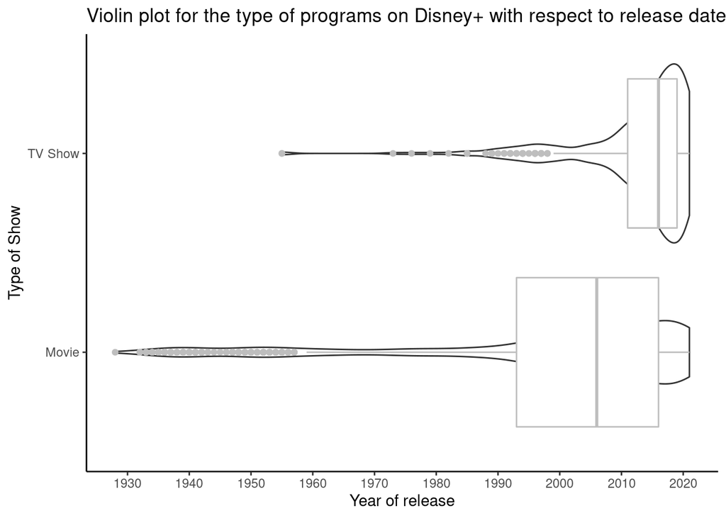

```r
ggplot(disneypluscontent_mutate, aes(x = release_year, y = type)) +
  geom_violin() + scale_fill_grey() + theme_classic() + geom_boxplot(color = "grey" )  +
  labs(title = "Violin plot for the type of programs on Disney+ with respect to release date",
       x = "Year of release",
       y = "Type of Show") +
  scale_x_continuous(breaks = seq(1920, 2020, by = 10))
```

### Visualization 2: Waffle Plot

**This plot uses Dataset #1.**

Create a waffle plot to show the distribution of program `type` on Disney+.

- Give the plot the title “Streaming Content on Disney+”.
- Change the colors of the squares to something other than the defaults.
- Use an x-axis label to indicate roughly how many programs each square represents.

Hint: Use `round(100 * prop.table(table(DATASETNAME$VARIABLENAME)))` to create the input data for the waffle plot. Swap out the capital letter placeholders for the correct dataset name and variable name.

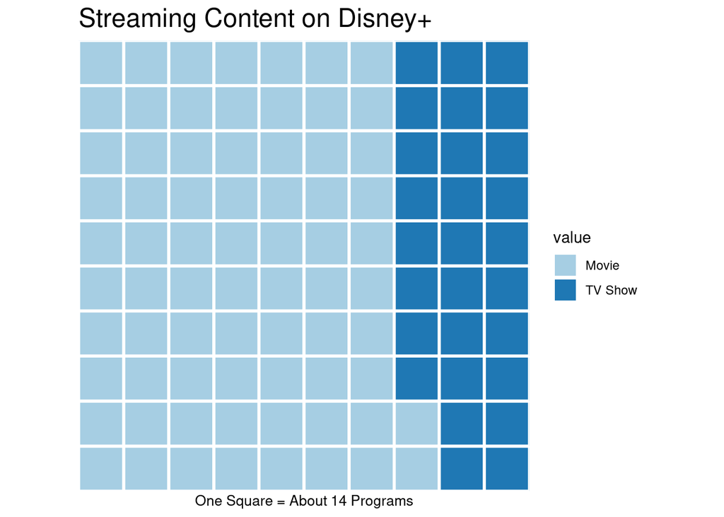

```r
waffle(round(100 * prop.table(table(disneypluscontent_mutate$type))),
       rows = 10, size = 1, xlab = "") +
  labs(title = "Streaming Content on Disney+",
       x = "One Square = About 14 Programs") +
  scale_fill_brewer(palette = "Paired")
```

### Visualization 3: Ratings Bar Plot

**This plot uses Dataset #1.**

Create a horizontal barplot to show the frequencies of the various `rating` categories for programs on Disney+ (i.e., use `y =` rather than `x =` for the variable you are plotting). **You will need to remove a couple `NA` values first.** Facet by `type` so that you have side-by-side plots for the two different program types. Add an appropriate title and axis labels, as well as other formatting to enhance effectiveness/appearance.

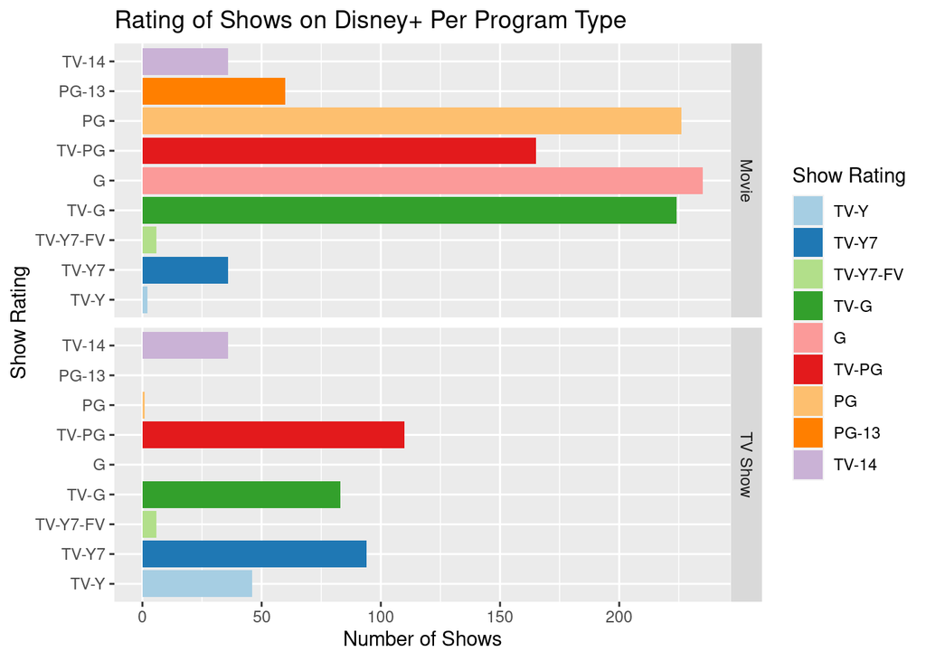

```r
disneyplusratings_mutate <- disneypluscontent_mutate %>% drop_na(rating)

ratingsbarplot <-
  ggplot(disneyplusratings_mutate,
         aes(y = rating, fill = rating)) +
  geom_bar() +
  scale_fill_brewer(palette = "Paired") +
  facet_grid(type ~ .) +
  labs(title = "Rating of Shows on Disney+ Per Program Type",
       x = "Number of Shows",
       y = "Show Rating",
       fill = "Show Rating")

ratingsbarplot
```

### Visualization 4: Services Bar Plot

**This plot uses Dataset #2.**

Create a barplot to display how many shows are offered on each of the four streaming services. Choose appropriate colors, labels, themes, and/or and other types of formatting that you feel will enhance the meaning or visual appearance of the plot.

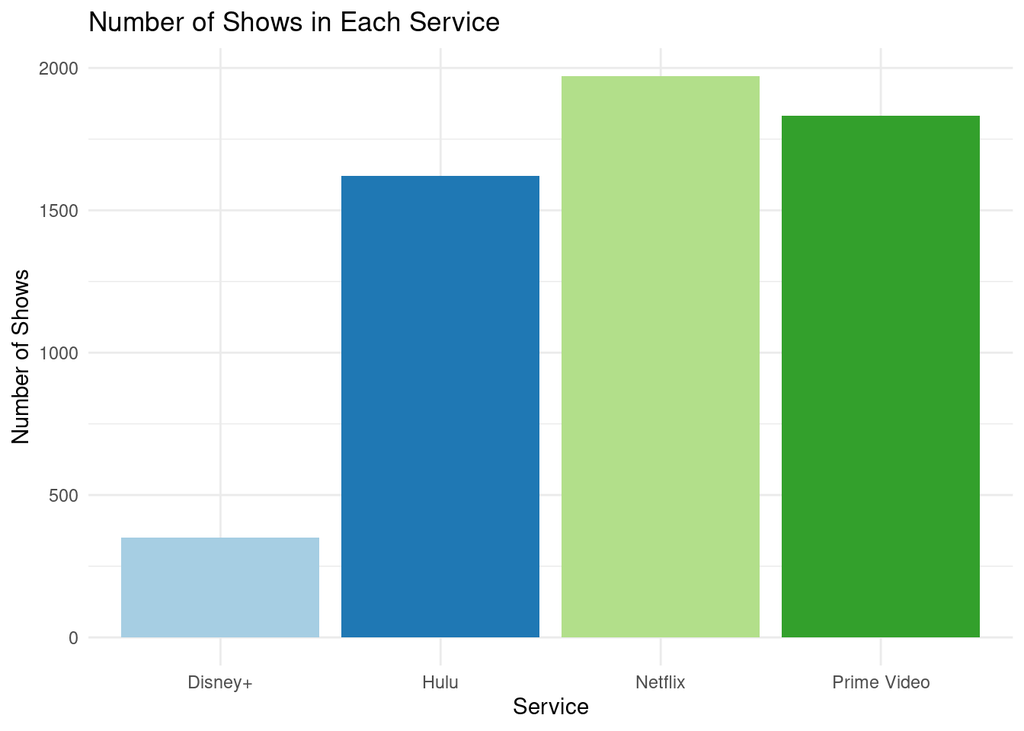

```r
services_barplot <-
  ggplot(streamingcontent_longer,
         aes(x = Service, fill = Service)) +
  geom_bar() +
  theme_minimal() +
  scale_fill_brewer(palette = "Paired") +
  labs(title = "Number of Shows in Each Service",
       y = "Number of Shows") +
  theme(legend.position = "none")

services_barplot
```

### Visualization 5: Choose a Plot!

Create one other plot of your choice using either dataset to explore a question of interest. You are welcome to perform additional manipulations on the data, if needed. Add an appropriate title and axis labels, as well as any other necessary formatting.

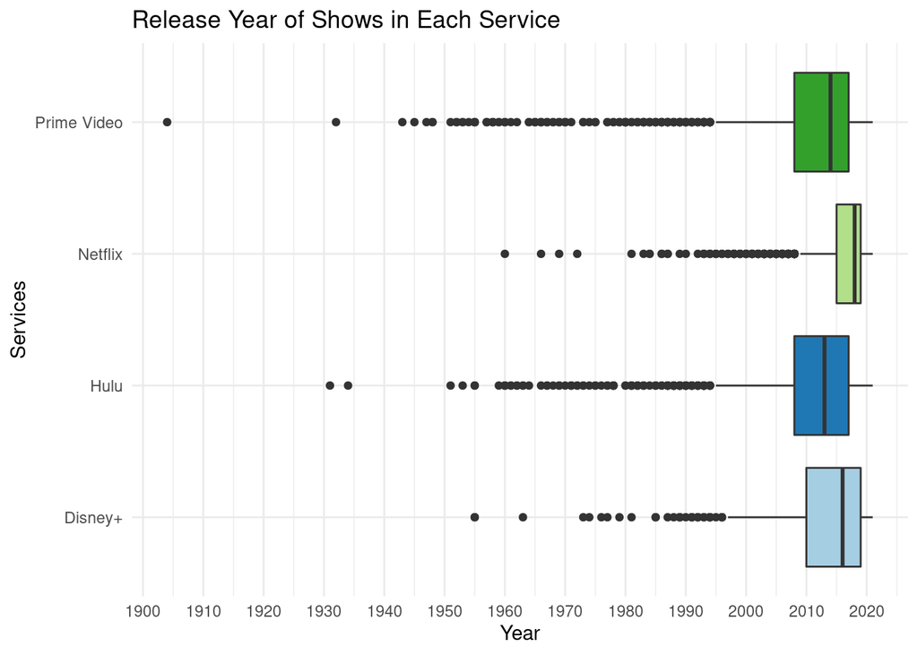

```r
  ggplot(streamingcontent_longer,
         aes(x = Year, y = Service, fill = Service)) +
  geom_boxplot() +
  theme_minimal() +
  scale_fill_brewer(palette = "Paired") +
  labs(title = "Release Year of Shows in Each Service",
       y = "Services") +
  scale_x_continuous(breaks = seq(1900, 2020, by = 10)) +
  theme(legend.position = "none")
```

## Questions

**Question 1:** Based on your plots, make five informational statements or comparisons regarding the Disney+ streaming service.

**Question 2:** What other data would you like to have, or which existing variables would you like to see transformed, if you were going to do further explorations or visualizations? Give at least two examples.

**ANSWER**

We would have liked to have been able to explore the different genres for both of the datasets. It would have been nice to transform dataset 1 to be able to analyze the genres they offer and to have the genres for dataset 2 and observe what genres are more prominent on what streaming service.

**Question 3:** Explain the rationale behind the choices you made with regard to plot type, formatting, and so on, when you created Visualization 5. What motivated your decisions?

**ANSWER**

We wanted to create a similar plot to observe the release years of shows on a streaming service as we did with dataset 1. We wanted to be able to compare the release years of the programs offered in each streaming service. We were able to create four boxplots to compare how the release years for the programs in each streaming service compared to one another. The color scheme follows the previous one used for Visualization 4, to maintain continuity between the plots. The x-axis also has the years going up by decade, starting from 1900 to 2020 and `theme_minimal()` was called to bring more attention to the boxplots and not overshadow them. There is no legend, as the legend would only state was is already stated on the y-axis. It would just distract from the visualization and add no new information.